# Classification w/ Decision Trees

## Training the Decision Tree

We will be using the tree and caret packages to perform our training. The basic idea behind a decision tree is to identify critical points in a variable’s value that influence it to be more of a yes vs a no in terms of classifying.

1. I use caret’s createDataPartition command to create a 70/30 split to train/test on (train on 70% / test on 30%)

```r
## Set Training Data
dataIndex <- createDataPartition(dataModel$win, p = .7, list = FALSE) #Creates a list containing 70% of the records and puts them into a vector

dataTrain <- dataModel[dataIndex, ] # Selects the rows of our dataset we want to train(which are the 70% we chose in our dataIndex line)

paged_table(dataTrain)
```

|  | win | gold_per_min | net_worth | gold | kills | tower_damage | duration | lane | lane_role |
| --- | --- | --- | --- | --- | --- | --- | --- | --- | --- |
| 1 | FALSE | 569 | 15770 | 1140 | 3 | 1221 | 1754 | 1 | 3 |
| 2 | FALSE | 549 | 15317 | 892 | 3 | 1559 | 1794 | 1 | 3 |
| 3 | TRUE | 654 | 16985 | 3210 | 10 | 19823 | 1547 | 3 | 3 |
| 5 | TRUE | 894 | 40098 | 9648 | 10 | 28469 | 2938 | 3 | 1 |
| 6 | TRUE | 593 | 21647 | 6622 | 5 | 10388 | 2435 | 3 | 1 |
| 8 | FALSE | 434 | 9842 | 1192 | 0 | 6657 | 1315 | 3 | 3 |
| 10 | TRUE | 752 | 24276 | 2576 | 13 | 9039 | 2263 | 3 | 3 |
| 11 | TRUE | 810 | 22700 | 2700 | 10 | 7885 | 1701 | 3 | 1 |
| 14 | FALSE | 902 | 41321 | 3596 | 16 | 11169 | 3349 | 1 | 1 |
| 15 | TRUE | 721 | 18818 | 2243 | 22 | 4646 | 1533 | 3 | 1 |

[output cut: 129 more lines]

```r
## Set Testing Data
dataTest <- dataModel[-dataIndex, ] #Selects rows of our dataset that were not used for training
paged_table(dataTest)
```

|  | win | gold_per_min | net_worth | gold | kills | tower_damage | duration | lane | lane_role |
| --- | --- | --- | --- | --- | --- | --- | --- | --- | --- |
| 4 | FALSE | 472 | 10399 | 449 | 4 | 1264 | 1319 | 1 | 1 |
| 7 | FALSE | 442 | 11580 | 2130 | 0 | 11727 | 1846 | 1 | 1 |
| 9 | TRUE | 701 | 26720 | 4570 | 9 | 18541 | 2332 | 1 | 3 |
| 12 | TRUE | 483 | 15927 | 2377 | 1 | 18953 | 1957 | 3 | 3 |
| 13 | TRUE | 676 | 10746 | 1641 | 11 | 9049 | 934 | 3 | 1 |
| 17 | TRUE | 412 | 12732 | 4407 | 0 | 8942 | 2002 | 3 | 3 |
| 25 | FALSE | 646 | 22515 | 1215 | 5 | 5258 | 2200 | 1 | 1 |
| 31 | TRUE | 672 | 18876 | 651 | 11 | 9172 | 1672 | 1 | 1 |
| 33 | TRUE | 808 | 27482 | 3307 | 6 | 14326 | 2083 | 3 | 1 |
| 36 | TRUE | 723 | 26798 | 1273 | 9 | 15706 | 2278 | 1 | 1 |

[output cut: 49 more lines]

2. I train our decision tree and print out a summary of the tree.

```r
#Train our Decision Tree
classTreeFit <- tree(win ~ ., data = dataTrain)
summary(classTreeFit)
```

```
##
## Classification tree:
## tree(formula = win ~ ., data = dataTrain)
## Variables actually used in tree construction:
## [1] "tower_damage" "duration"     "gold"         "kills"        "net_worth"
## [6] "gold_per_min"
## Number of terminal nodes:  13
## Residual mean deviance:  0.3518 = 44.32 / 126
## Misclassification error rate: 0.07914 = 11 / 139
```

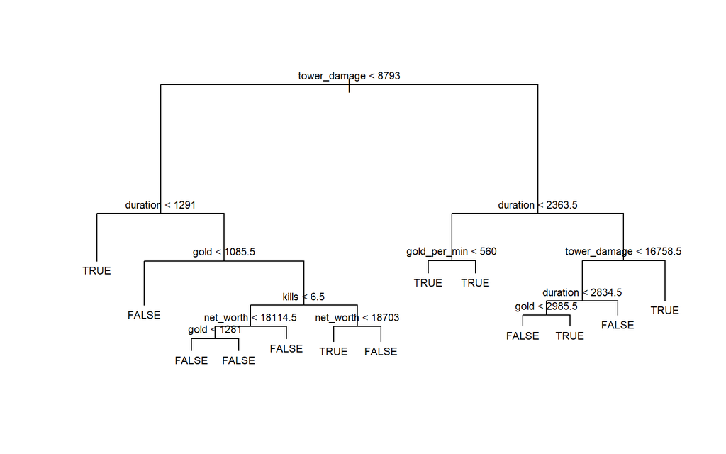

```r
#Plot it and admire its beauty
plot(classTreeFit, show.node.label=TRUE)
text(classTreeFit,pretty=0,cex=0.7)
```

[output not shown]

3. Post-pruning

```r
#Pruning Our Tree

##Getting the misclass rate
pruneFit <- cv.tree(classTreeFit, FUN = prune.misclass)
pruneFit
```

```
## $size
## [1] 13 10  9  7  5  3  2  1
##
## $dev
## [1] 31 31 31 35 38 37 32 63
##
## $k
## [1] -Inf  0.0  1.0  1.5  2.0  2.5  7.0 31.0
##
## $method
## [1] "misclass"
##
## attr(,"class")
## [1] "prune"         "tree.sequence"
```

```r
##
dfPruneFit <- cbind(size=pruneFit$size,dev=pruneFit$dev) #Grabbing the Size and Dev classes as these show the least amount of 'deviations' aka bad classifications and the relative size.
dfPruneFit <- data.frame(dfPruneFit)
dfPruneFit <- dfPruneFit %>% group_by(size)%>%arrange(size)%>%arrange(dev)
dfPruneFit
```

```
## # A tibble: 8 × 2
## # Groups:   size [8]
##    size   dev
##   <dbl> <dbl>
## 1     9    31
## 2    10    31
## 3    13    31
## 4     2    32
## 5     7    35
## 6     3    37
## 7     5    38
## 8     1    63
```

```r
bestVal <- dfPruneFit$size[1] #Sets our best number of tree branches to a variable to use later

# Using our pruned misclass rate to alter our training
pruneFitFinal <- prune.misclass(classTreeFit, best = bestVal) #Use our bestVal to prune our tree
summary(pruneFitFinal)
```

```
##
## Classification tree:
## snip.tree(tree = classTreeFit, nodes = c(6L, 22L, 23L))
## Variables actually used in tree construction:
## [1] "tower_damage" "duration"     "gold"         "kills"
## Number of terminal nodes:  9
## Residual mean deviance:  0.4848 = 63.02 / 130
## Misclassification error rate: 0.08633 = 12 / 139
```

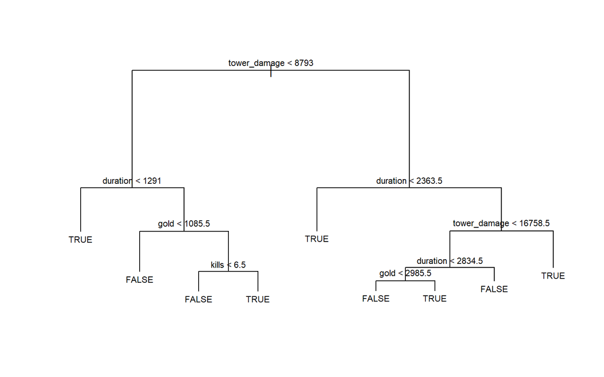

```r
plot(pruneFitFinal, show.node.label=TRUE)
text(pruneFitFinal,pretty=0,cex=0.7)
```

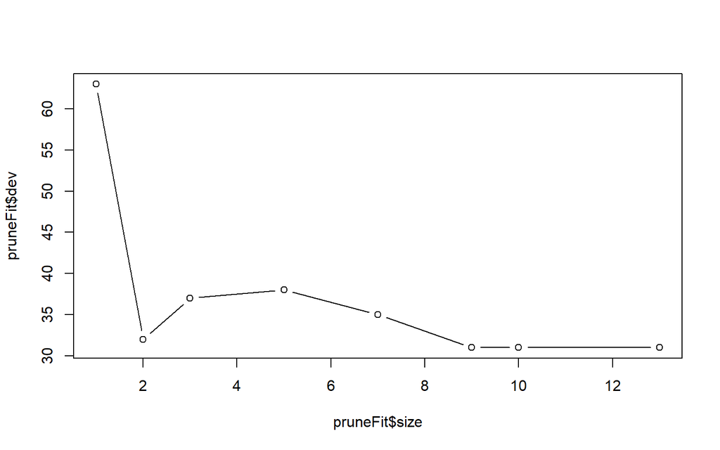

```r
## Prune Graph Generate
plot(pruneFit$size, pruneFit$dev, type = "b")
```